# Week 03: Sampling Variation

## How to import in R datasets used in the textbook

```r
install.packages("abd") #First install the abd library that is a companion to the abd textbook.
library(abd)
library(tidyverse) # you can also load directly tidyverse

data("HumanGeneLengths") # loading in R the human gene length dataset
```

## Sampling from ideal and empirical idealized distributions

Ideal, probability distribution

```r
myRandomNumbers = rnorm(n = 10^4, mean=0, sd=1) # In one go you generate 10^4 draws from a standard normal distribution
```

NB: R is very good at generating draws from a while suite of probabilty distributions (more on that in week 4)

### Q1: Using ggplot, make a histogram of these 10^4 draws, check different binning options

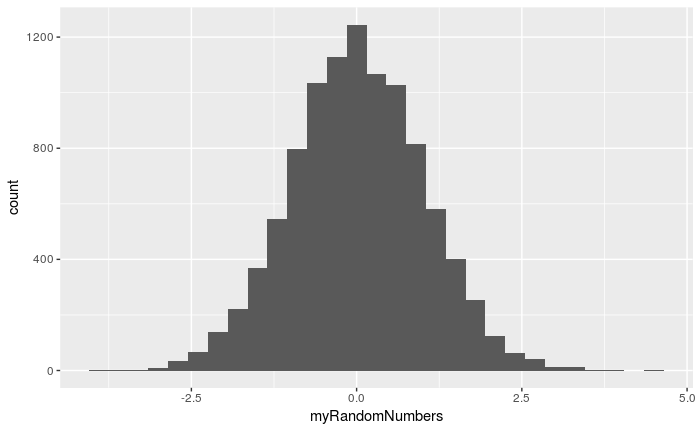

```r
qplot(myRandomNumbers, geom="histogram", binwidth = 0.3)
```

## An empirical distribution used in the book

```r
summary(HumanGeneLengths)
```

```
  gene.length
 Min.   :   60
 1st Qu.: 1312
 Median : 2226
 Mean   : 2622
 3rd Qu.: 3444
 Max.   :99631
```

### Q: What is the unit of gene length?

Base pairs

### Q2: Using ggplot, make a histogram that mimicks the figure of the book for human gene length

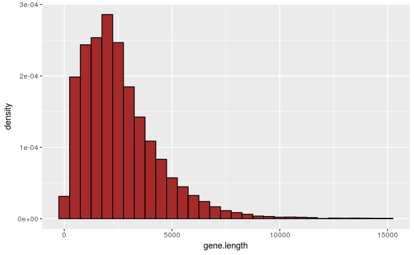

```r
plot1 <- filter(HumanGeneLengths, gene.length < 15000) %>%
    ggplot() +
    geom_histogram(mapping = aes(x = gene.length, ..density..), binwidth = 500, color = "black", fill = "brown")
plot1
```

TO do so use the scale_x_continuous and scale_y_continuous option in ggplot

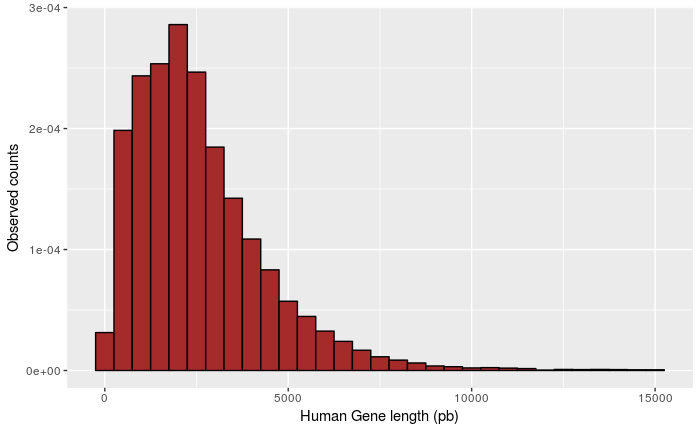

```r
plot1 + scale_x_continuous("Human Gene length (pb)") + scale_y_continuous("Observed counts")
```

## Sampling from an empirical (finite) distribution

```r
MySmallSample= sample(x = HumanGeneLengths$gene.length, size = 30, replace = T) ## 30 genes sampled WITH replacement
```

### Q What is the diffference between sampling with and without replacement?

With replacement you can get the same individual twice.

### Q What is the line of code below doing ?

```r
MyBigSample= sample(x = HumanGeneLengths$gene.length, size = length(HumanGeneLengths$gene.length), replace = F)
summary(MyBigSample)
```

```
   Min. 1st Qu.  Median    Mean 3rd Qu.    Max.
     60    1312    2226    2622    3444   99631
```

It is taking all the Human Gene Lengths and printing a summary of the data. This is called the random permutation.